# R Notebook

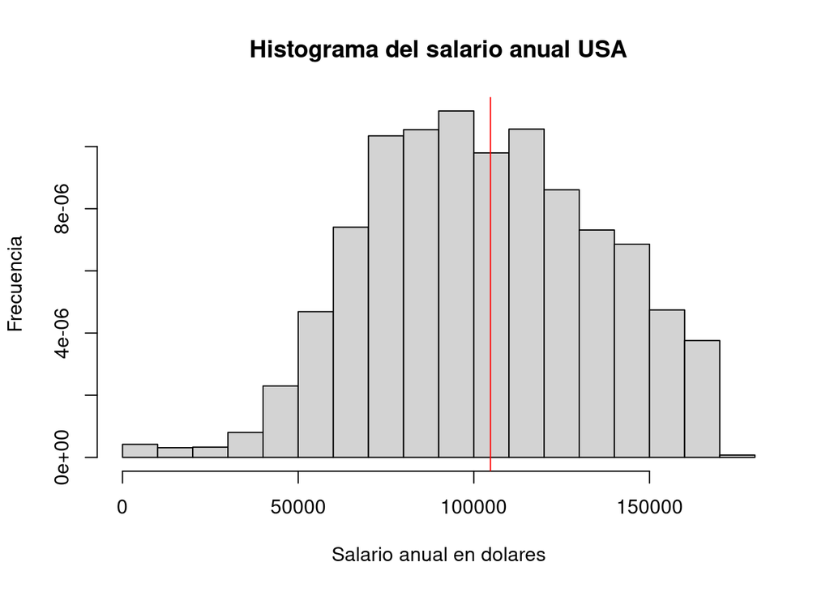

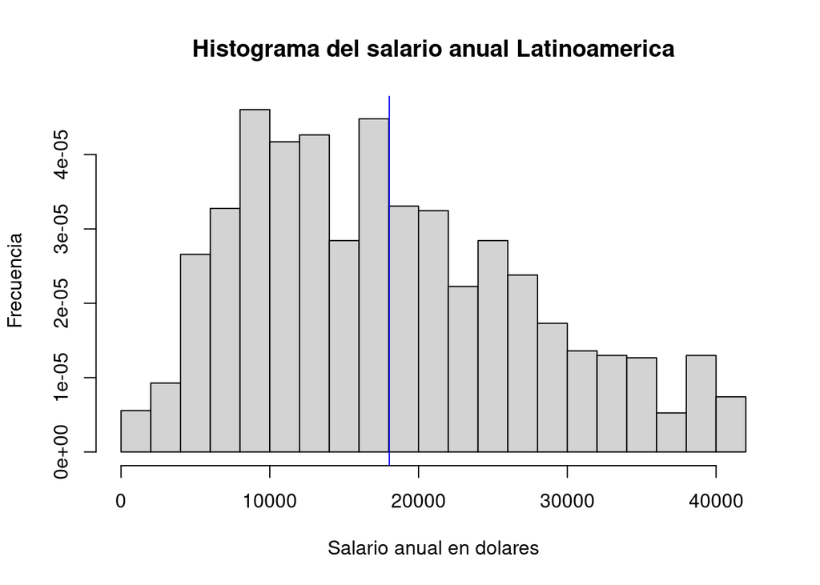

```r
hist(DF_FT_LA_STD$ConvertedComp, breaks = 15, probability = TRUE, main = "Histograma del salario anual Latinoamerica", ylab = "Frecuencia", xlab = "Salario anual en dolares")

abline(v=mean(DF_FT_LA_STD$ConvertedComp, na.rm = TRUE), col = "blue")
```

En Estados Unidos se observa una distribución normal respecto a la media, es decir que la mayoría de los programadores gana alrededor de 104737 dólares anuales. Por otro lado, en América Latina no existe una distribución muy atípica, pero sí hay más variación respecto a la media, a comparación de Estados Unidos.

```r
mean_comp_usa = round(mean(DF_FT_USA_STD$ConvertedComp, na.rm = TRUE),2)
mean_comp_usa
```

```
[1] 104737.8
```

```r
mean_comp_la = round(mean(DF_FT_LA_STD$ConvertedComp, na.rm = TRUE), 2)
mean_comp_la
```

```
[1] 18034.17
```

Asimismo, se resalta la diferencia entre la media de USA y América Latina, que en USA es el 580.77% de la de América Latina.

```r
round(mean_comp_usa/mean_comp_la*100,2)
```

```
[1] 580.77
```

Calculamos las medianas porque nos permiten obtener un valor “medio”, que es afectado en mucho menor grado que la media por los datos atípicos.

```r
median_comp_usa = round(median(DF_FT_USA_STD$ConvertedComp, na.rm = TRUE),2)
median_comp_usa
```

```
[1] 104000
```

```r
median_comp_la = round(median(DF_FT_LA_STD$ConvertedComp, na.rm = TRUE), 2)
median_comp_la
```

```
[1] 16488
```

```r
round(median_comp_usa/median_comp_la*100,2)
```

```
[1] 630.76
```

A partir del análisis, se plantea la hipótesis de que existe una abismal diferencia en cuanto la remuneración total anual entre los programadores full-time que viven en Estados Unidos y los que viven en América Latina. Siendo mucho mayor para Estados Unidos.

#### Preguntas que involucran relaciones entre variables

##### ¿Existe diferencia entre la relación que hay entre la edad de los desarrolladores profesionales y los años que llevan programando profesionalmente?

Utilizamos las variables de Años programando profesionalmente y edad para responder esta pregunta.

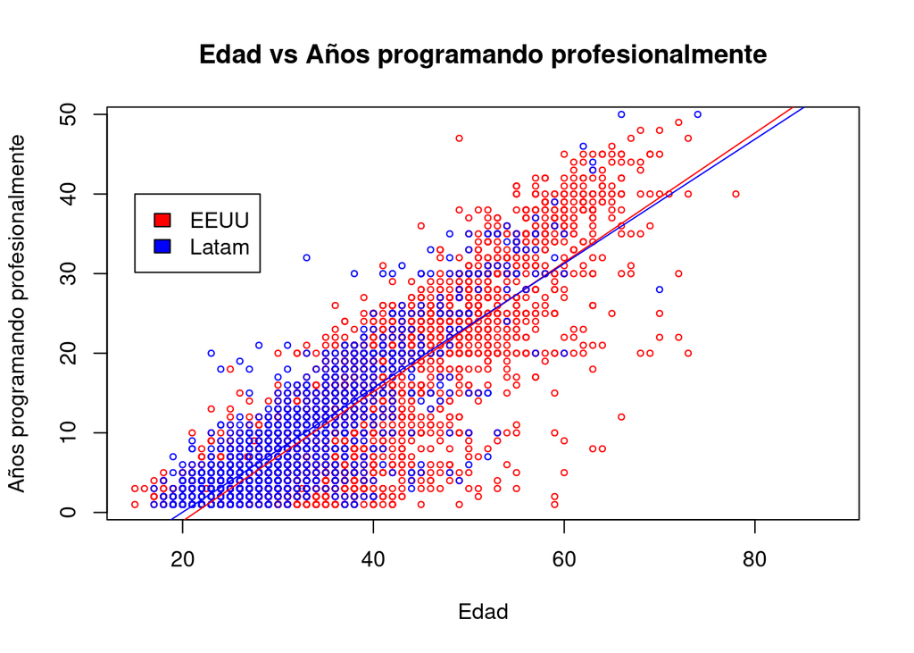

```r
plot(x = DF_USA$Age, y = DF_USA$YearsCodePro, col = "red", cex = 0.6, xlab = "Edad", ylab = "Años programando profesionalmente", main = "Edad vs Años programando profesionalmente")
points(x = DF_LA$Age, y = DF_LA$YearsCodePro, col = "blue", cex = 0.6)
legend(15, 40, legend = c("EEUU", "Latam"), fill=c("red", "blue"))

abline(lm(DF_USA$YearsCodePro ~ DF_USA$Age), col = "red")
abline(lm(DF_LA$YearsCodePro ~ DF_LA$Age), col = "blue")
```

Se decidió utilizar un diagrama de dispersión con colores porque permite observar la correlación entre dos variables y además permite diferenciar con colores variables categóricas. En el gráfico se puede observar que existe una fuerte relación entre la edad y los años de experiencia y que la pendiente es similar entre las regiones. Se puede utilizar la covarianza para medir el grado de asociaron que existen entre las variables y se puede ver que es positiva y hay asociación, las dos variables crecen en la misma dirección.

```r
cov(y = DF_USA$Age,x = DF_USA$YearsCodePro, use = "pairwise.complete.obs")
```

```
[1] 76.9334
```

```r
cov(y = DF_LA$Age,x = DF_LA$YearsCodePro, use = "pairwise.complete.obs")
```

```
[1] 44.56676
```

Sin embargo, si se desea comparar la relación entre las dos regiones, se tiene que usar la correlación, pues en este descriptor no influye la escala pues está dividida por el promedio de los datos. Con la correlación podemos ver que es bastante similar y que, además en las dos regiones es bastante alta.

```r
cor(x = DF_USA$Age,y = DF_USA$YearsCodePro, use = "pairwise.complete.obs")
```

```
[1] 0.8703693
```

```r
cor(x = DF_LA$Age,y = DF_LA$YearsCodePro, use = "pairwise.complete.obs")
```

```
[1] 0.8382195
```

Gracias a la alta correlación, se pude determinar una función que permita “predecir” los años de experiencia en función de la edad de un programados:

- Estados Unidos: f(edad) = 0.81 × edad - 17.34
- América Latina: f(edad) = 0.78 × edad - 15.58

Luego de analizar la variable con los indicadores, se puede dar la hipótesis de que la región no influye entre la relación de la edad y años programando profesionalmente, además esta es muy alta y sugeriría que los programadores profesionales comienzan a trabajar a una temprana edad lo que permite que ganen años de experiencia mientras aumenta su edad.

##### ¿Cuál es la diferencia entre regiones de la relación que existe entre la edad y la remuneración anual de los programadores profesionales que trabajan tiempo parcial?

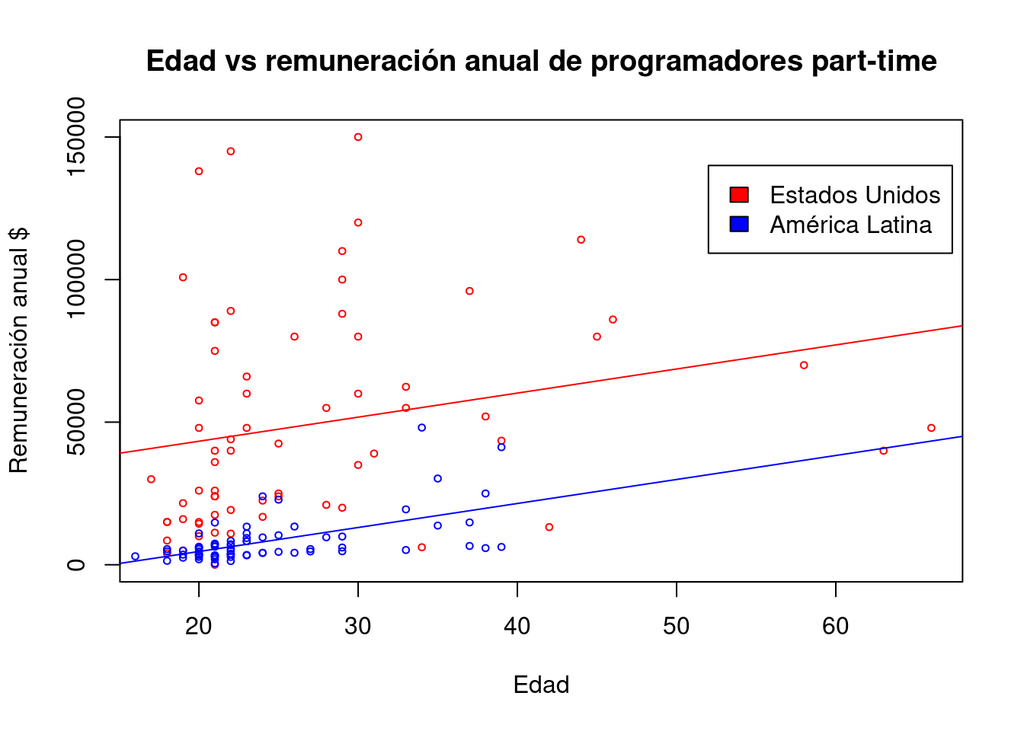

```r
DF_LA_FREE <- DF_MIX[DF_MIX$Region == "América Latina" & DF_MIX$isStandard_mix == TRUE & DF_MIX$Employment == "Employed part-time", ]
DF_USA_FREE <- DF_MIX[DF_MIX$Region == "Estados Unidos" & DF_MIX$isStandard_mix == TRUE & DF_MIX$Employment == "Employed part-time", ]

plot(x = DF_USA_FREE$Age, y = DF_USA_FREE$ConvertedComp, col = "red", cex = 0.6, main = "Edad vs remuneración anual de programadores part-time", xlab = "Edad", ylab = "Remuneración anual $")
points(x = DF_LA_FREE$Age, y = DF_LA_FREE$ConvertedComp, col = "blue", cex = 0.6)
legend(52, 140000, legend = c("Estados Unidos", "América Latina"), fill=c("red", "blue"))
abline(lm(DF_USA_FREE$ConvertedComp ~ DF_USA_FREE$Age), col = "red")
abline(lm(DF_LA_FREE$ConvertedComp ~ DF_LA_FREE$Age), col = "blue")
```

Al igual que en el anterior caso, se optó por utilizar un diagrama de dispersión con colores para diferenciar la variable categórica de la región. Se puede apreciar en el cuadro que ambas variables parecen tener cierta relación, para verificar esto se analizara el valor de la covarianza. Se puede ver que ambas son positivas, sin embargo, el valor de la covarianza de Estados Unidos es mucho mayor que la de América Latina.

```r
cov(x = DF_USA_FREE$Age,y = DF_USA_FREE$ConvertedComp, use = "pairwise.complete.obs")
```

```
[1] 91061.62
```

```r
cov(x = DF_LA_FREE$Age,y = DF_LA_FREE$ConvertedComp, use = "pairwise.complete.obs")
```

```
[1] 27886.52
```

Para poder comparar ambas relaciones, pues ya se ha analizado que el sueldo de los programadores en Estados Unidos es mucho mayor, se utilizará la correlación, que permite comparar en proporción a la media de las variables, y podemos ver que, que la correlación en Estados Unidos es menos de la mitad que en América Latina.

```r
cor(x = DF_USA_FREE$Age,y = DF_USA_FREE$ConvertedComp, use = "pairwise.complete.obs")
```

```
[1] 0.2362047
```

```r
cor(x = DF_LA_FREE$Age,y = DF_LA_FREE$ConvertedComp, use = "pairwise.complete.obs")
```

```
[1] 0.5742046
```

##### ¿Cuál es la diferencia que exise entre regiones de la relación entre los años de experiencia y el sueldo de los programadores que traban en empresas pequeñas?

Para responder a esta pregunta, se seleccionaron las variables de remuneración anual y años programando profesionalmente de las observaciones que tienen en la variable del tamaño de la organización como que trabajan en una empresa de entre 2 a 9 empleados o de 10 a 19 y una vez más se usó solo a los programadores que contaban con un sueldo “estándar” norteamericano según la variable booleana que fue definida anteriormente.

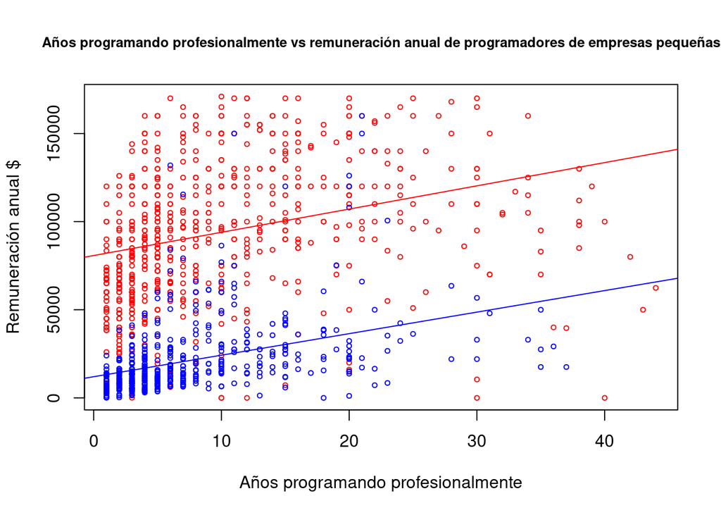

```r
DF_LA_FREE <- DF_MIX[(DF_MIX$Region == "América Latina" & DF_MIX$isStandard_mix == TRUE & (DF_MIX$OrgSize == "2 to 9 employees" |DF_MIX$OrgSize == "10 to 19 employees")), ]
DF_USA_FREE <- DF_MIX[(DF_MIX$Region == "Estados Unidos" & DF_MIX$isStandard_mix == TRUE & (DF_MIX$OrgSize == "2 to 9 employees" |DF_MIX$OrgSize == "10 to 19 employees")), ]

plot(x = DF_USA_FREE$YearsCodePro, y = DF_USA_FREE$ConvertedComp, col = "red", cex = 0.6, main = "Años programando profesionalmente vs remuneración anual de programadores de empresas pequeñas", cex.main = 0.8, xlab = "Años programando profesionalmente", ylab = "Remuneración anual $")
points(x = DF_LA_FREE$YearsCodePro, y = DF_LA_FREE$ConvertedComp, col = "blue", cex = 0.6)

abline(lm(DF_USA_FREE$ConvertedComp ~ DF_USA_FREE$YearsCodePro), col = "red")
abline(lm(DF_LA_FREE$ConvertedComp ~ DF_LA_FREE$YearsCodePro), col = "blue")
```

Se decidió utilizar un diagrama de dispersión por colores por los motivos ya mencionados anteriormente. Se puede observar en el diagrama que la regresión lineal tiene pendiente positiva en ambos casos. Se recurre a las covarianzas para ver el grado de asociación en las variables y se ve que en ambos casos es positiva, lo que indicaría que las variables crecen en la misma dirección.

```r
cov(x = DF_USA_FREE$YearsCodePro,y = DF_USA_FREE$ConvertedComp, use = "pairwise.complete.obs")
```

```
[1] 103577.2
```

```r
cov(x = DF_LA_FREE$YearsCodePro,y = DF_LA_FREE$ConvertedComp, use = "pairwise.complete.obs")
```

```
[1] 63155.84
```

Como se desea identificar una diferencia se hará uso, una vez más, de la correlación que permite eliminar el hecho de que el sueldo de por si es más bajo en América Latina que en Estados Unidos. Se puede observar que la correlación es baja en el caso del país del norte, pero es moderada en el caso de la región del sur.

```r
cor(x = DF_USA_FREE$YearsCodePro,y = DF_USA_FREE$ConvertedComp, use = "pairwise.complete.obs")
```

```
[1] 0.3045204
```

```r
cor(x = DF_LA_FREE$YearsCodePro,y = DF_LA_FREE$ConvertedComp, use = "pairwise.complete.obs")
```

```
[1] 0.4008535
```

### Modelos de variable aleatoria para variables de interés

#### Probabilidad de que un desarrollador profesional de Estados Unidos o de América latina tenga un sueldo anual “estándar”

Anteriormente se definió utilizando fuentes bibliográficas y el gráfico original, una variable booleana que nos permite definir si un programador posee un sueldo anual “estándar” o no. Utilizando esta variable se puede definir una variable aleatoria discreta que se distribuye en una Bernoulli p. Cuando un programador gane un sueldo estándar, será considerado un exito, y cuando gane más del será un fracaso. Se calcula la probabilidad de éxito par ambas regiones:

```r
totalUSA <- nrow(DF_FT_USA)
totalUSA_std <- nrow(DF_FT_USA[DF_FT_USA$isStandard_usa == TRUE,])
totalLA <- nrow(DF_FT_LA)
totalLA_std <- nrow(DF_FT_LA[DF_FT_LA$isStandard_la == TRUE,])


round(dbern(1, totalUSA_std/totalUSA),2)
```

```
[1] 0.84
```

```r
round(dbern(1, totalLA_std/totalLA),2)
```

```
[1] 0.91
```

Se puede observar que la probabilidad de que al elegir un programador profesional en Estados Unidos este gane un sueldo considerado estándar es de 0.84. Mientras que si hacemos este experimento en América Latina, la probabilidad es de 0.91, esto indica que quizá el sueldo estándar, que se obtuvo de la fuente bibliográfica y se corroboró con el gráfico, podría estar un poco por debajo de un supuesto sueldo estándar real.

#### Probabilidad de que un desarrollador profesional de Estados Unidos o de América latina trabaje en una empresa que cuente con un buen proceso de incorporación

A continuación se utilizará la variable ordinal “proceso de incorporación” que tiene 3 categorías para indicar si es que el proceso de incorporación de la empresa en donde trabajan los programadores profesionales tienen un buen proceso de incorporación, estas son: “Sí”, “No” y “¿Cuál proceso?. Se tomará como una variable aleatoria tiene una distribución Bernoulli p, donde se considerará como éxito cuando un trabajador responde”Sí" a la pregunta si es que proceso de incorporación de su empresa es bueno y se tomará como fracaso cualquier otra respuesta (No o ¿Cuál proceso?).

```r
totalUSA_yes <- nrow(DF_USA[DF_USA$NEWOnboardGood == "Yes" & !is.na(DF_USA$NEWOnboardGood),])
totalUSA <- nrow(DF_USA[!is.na(DF_USA$NEWOnboardGood),])
totalLA_yes <- nrow(DF_LA[DF_LA$NEWOnboardGood == "Yes" & !is.na(DF_LA$NEWOnboardGood),])
totalLA <- nrow(DF_LA[!is.na(DF_LA$NEWOnboardGood),])

round(dbern(1, totalUSA_yes/totalUSA),2)
```

```
[1] 0.5
```

```r
round(dbern(1, totalLA_yes/totalLA),2)
```

```
[1] 0.44
```

Se puede apreciar que la probabilidad de que al escoger un programador en Estados Unidos o en América Latina la empresa donde trabaja tenga un buen proceso de incorporación es bastante similar. Se puede extender este experimento para aplicar una distribución binomial, y mostrar las probabilidades de obtener de 1 a 10 programadores cuya empresa tenga un buen proceso de incorporación al escogerlos de un grupo de 10.

```r
data.frame("n_éxito"=c(1:10), "prob" = round(dbinom(c(1:10), 10, totalUSA_yes/totalUSA),3))
```

| n_éxito | prob |
| --- | --- |
| 1 | 0.010 |
| 2 | 0.044 |
| 3 | 0.118 |
| 4 | 0.205 |
| 5 | 0.246 |
| 6 | 0.205 |
| 7 | 0.117 |
| 8 | 0.044 |
| 9 | 0.010 |
| 10 | 0.001 |

Se puede ver que en Estados unidos lo más probable es que 5 programadores de los 10 elegidos trabajen en una empresa con un buen proceso de incorporación

```r
data.frame("n_éxito"=c(1:10), "prob" = round(dbinom(c(1:10), 10, totalLA_yes/totalLA),3))
```

| n_éxito | prob |
| --- | --- |
| 1 | 0.024 |
| 2 | 0.085 |
| 3 | 0.177 |
| 4 | 0.243 |
| 5 | 0.228 |
| 6 | 0.149 |
| 7 | 0.067 |
| 8 | 0.020 |
| 9 | 0.003 |
| 10 | 0.000 |

Por otro lado, en América Latina, lo más probable sea que 4 de los 10 trabajen en una orgacicacion con un buen acoplamiento.

### Bibliografía

- BBC new. (2019). Cuáles son los países donde la gente trabaja más y menos horas semanales (y qué quieren cambiar en Chile). Recuperado de https://www.bbc.com/mundo/noticias-49411425.
- Internal Revenue Service. (2021). Identifying Full-time Employees. Recuperado de https://www.irs.gov/affordable-care-act/employers/identifying-full-time-employees
- ZipRecruiter (2020). Software Developer Salary. Recuperado de: https://www.ziprecruiter.com/Salaries/Software-Developer-Salary
- Evalart (2019). Cuánto ganan los desarrolladores en América Latina. Recuperado de: https://evalart.com/es/blog/cuanto-ganan-los-desarrolladores-en-america-latina/#:~:text=Por%20%C3%BAltimos%20se%20encuentran%20los,ganar%20hasta%203.170%2C00%20USD.